# PRESS 2016 - COUNTRY FACTSHEETS

```
                                       Chad
```

Download this factsheet as PDF

The PRESS exercise is conducted annually to report on trends across time in support to statistics. The 2016 PRESS uses newly available data from an annual donor survey and the Creditor Reporting System (CRS) round of 2014 to update figures on aid to statistics for 2006 to 2013 (previously reported in the 2015 PRESS) and report new figures for commitments in 2014. The new 2014 figures are expected to be adjusted upwards to the levels of previous years 2011-2013 as additional projects for 2014 will be reported later this year.All findings should therefore be interpreted with this caveat in mind.

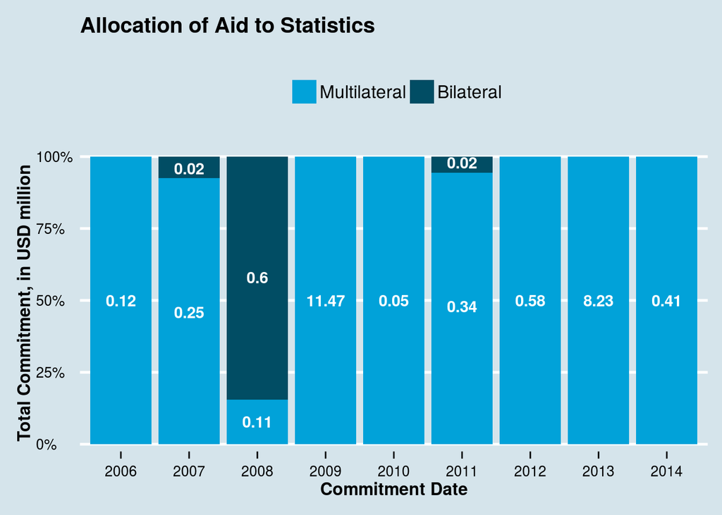

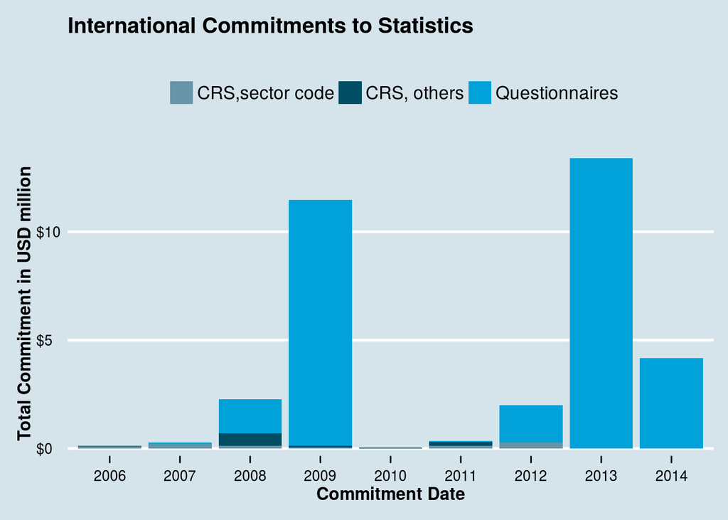

> Fig1. Allocation of Aid to Statistics

Multilateral[^1], country-specific assistance remains globally the most popular means through which donors channel support to countries. Considering all recipients reported in the PRESS, support from multilateral bodies accounted for less than 50% of total aid to statistics in 2009-2010 but increased to approximately 70% in 2011 and 2012, respectively. However, the shares of country-specific[^2] aid diminished slightly between 2012 and 2014.

> Fig2. International Commitments to Statistics

Support to statistics remains globally low. Considering all recipients reported in the PRESS, total 2014 commitments to statistical development of about USD 470 million show a 20% decrease from previous years 2011 and 2013. The decrease in commitments in 2014 led to a drop in the share of ODA dedicated to statistics from 0.31% in 2012 and 2013 to 0.25% in 2014. This should, however, not be interpreted as a general trend because commitments often span multiple years and fluctuations in annual figures are therefore common

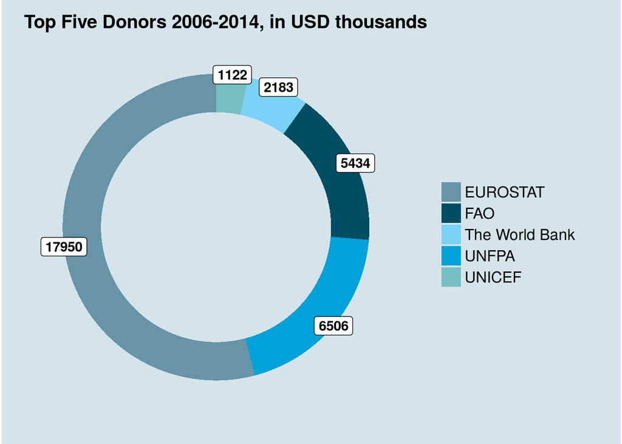

> Fig3. Top 5 Donors

A large share of global support to statistics continues to come from a very small number of providers. The top five providers of development co-operation in statistics for all countries reported in the PRESS (European Commission/EUROSTAT; The World Bank; IMF; FAO; Canada) provided 72% of total commitments in 2014. While Canada is strongly engaged in country-specific aid to statistics, the United Kingdom and Norway are among the top donors for unallocated commitments. Country-Specific commitments accounted for approximately 74% (USD 350 million) in 2014.

This table displays all projects whose Financing Amount is at least 10 000 USD.

| Provider | Projects | Amount | Type | Date |
| --- | --- | --- | --- | --- |
| **EUROSTAT** | ‘PAMFIP’ (Programme d’Appui à la Modernisation des Finances Publiques) | 209 | Grant | 2009 |
| **EUROSTAT** | SIDRAT - SYSTEME D’INFORMATION DEVELOPPEMENT | 11141 | Grant | 2009 |
| **EUROSTAT** | Recensement Général de l’Elevage | 257 | Grant | 2012 |
| **EUROSTAT** | Adressing food security for the poor in fragile situation - Information system | 5975 | Grant | 2013 |
| **EUROSTAT** | Programme d’Appui à la Bonne Gouvernance Démocratique et Financière - support to INSEED - first general census of companies | 368 | Grant | 2014 |
| **FAO** | Appui à la réalisation du Recensement Général de l`Elevage (RGE) | 266 | Grant | 2012 |
| **FAO** | Appui à la mise en place d`un Système d`Information durable sur la sécurité alimentaire et d`alerte précoce | 4514 | Grant | 2013 |
| **FAO** | Assistance préparatoire au Recensement Général de l`Agriculture (RGA) et au Recensement Général de l`Elevage (RGE) | 654 | Grant | 2013 |
| **Germany** | STATISTICAL CAPACITY BUILDING | 23 | Grant | 2007 |
| **IMF** | Technical Assistance | 59 |  | 2007 |
| **IMF** | Statistics Department: Technical Assistance | 32 |  | 2010 |
| **IMF** | Statistics Department: Technical Assistance | 54 |  | 2011 |
| **IMF** | Statistics Department: Technical Assistance | 55 |  | 2012 |
| **IMF** | Statistics Department: Technical Assistance | 73 |  | 2013 |
| **IMF** | Statistics Department: Technical Assistance | 39 |  | 2014 |
| **Switzerland** | TCHAD APPUI AU RECENSEMENT DE LA POPULATION | 128 | Grant | 2008 |
| **Switzerland** | TCHAD APPUI AU RECENSEMENT DE LA POPULATION | 461 | Grant | 2008 |
| **The World Bank** | CHAD Support to NSDS implementation | 483 | Grant | 2013 |
| **The World Bank** | Education Sector Reform Project Phase II | 1700 | Loan/credit | 2013 |
| **UNFPA** | Appui à la réalisation du Deuxième Recensement Général de la Population et de l’Habitat (RGPH2) | 1576 | Grant | 2008 |
| **UNFPA** | Strengthened national policies and international development agendas through integration of evidence-based analysis on population dynamics and their links to sustainable development, sexual and reprod… | 320 | Grant | 2012 |
| **UNFPA** | Strengthened national policies and international development agendas through integration of evidence-based analysis on population dynamics and their links to sustainable development, sexual and reprod… | 116 | Grant | 2012 |
| **UNFPA** | Increased national capacity to deliver comprehensive maternal health services | 246 | Grant | 2012 |
| **UNFPA** | Increased availability and use of integrated sexual and reproductive health services (including family planning, maternal health and HIV) that meet human rights standards for quality of care and equit… | 14 | Grant | 2012 |
| **UNFPA** | Increased availability and use of integrated sexual and reproductive health services (including family planning, maternal health and HIV) that meet human rights standards for quality of care and equit… | 237 | Grant | 2012 |
| **UNFPA** | Secured reproductive health medicines and products | 225 | Grant | 2012 |
| **UNFPA** | Strengthened national capacity for production and dissemination of quality disaggregated data on population and development issues that allows for mapping of demographic disparities and socio-economic… | 3772 | Grant | 2014 |
| **UNICEF** | CP DATA COLLECTION AND ANALYSIS | 25 | Grant | 2006 |
| **UNICEF** | DATABASES AND DATA DISSEMINATION | 23 | Grant | 2006 |
| **UNICEF** | KNOWLEDGE MGT. NETWORKS AND SYSTEMS (PARTNERS) | 18 | Grant | 2006 |
| **UNICEF** | BIRTH REGISTRATION (GENERAL) | 24 | Grant | 2006 |
| **UNICEF** | CP RESEARCH AND ANALYSIS | 24 | Grant | 2006 |
| **UNICEF** | RAPID ASSESSMENT SURVEYS IN EMERGENCIES | 22 | Grant | 2007 |
| **UNICEF** | DEVINFO DBASE DEVELOPMENT AND MAINTENANCE | 42 | Grant | 2007 |
| **UNICEF** | DATABASES AND DATA DISSEMINATION | 28 | Grant | 2007 |
| **UNICEF** | CP DATA COLLECTION AND ANALYSIS | 61 | Grant | 2007 |
| **UNICEF** | CP RESEARCH AND ANALYSIS | 18 | Grant | 2007 |
| **UNICEF** | CP NATIONAL AND SUB-NATIONAL PLANS AND REPORTS | 11 | Grant | 2007 |
| **UNICEF** | NATIONAL STATISTICAL SYSTEMS | 15 | Grant | 2008 |
| **UNICEF** | DEVINFO DBASE DEVELOPMENT AND MAINTENANCE | 14 | Grant | 2008 |
| **UNICEF** | DATABASES AND DATA DISSEMINATION | 56 | Grant | 2008 |
| **UNICEF** | BIRTH REGISTRATION | 20 | Grant | 2009 |
| **UNICEF** | DEVINFO DBASE DEVELOPMENT AND MAINTENANCE | 45 | Grant | 2009 |
| **UNICEF** | NATIONAL STATISTICAL SYSTEMS | 53 | Grant | 2009 |
| **UNICEF** | BIRTH REGISTRATION | 22 | Grant | 2010 |
| **UNICEF** | CHILD PROTECTION AND VIOLATIONS DATA COLLECTION, ANALYSIS, REPORTS AND USE | 138 | Grant | 2011 |
| **UNICEF** | BIRTH REGISTRATION | 14 | Grant | 2011 |
| **UNICEF** | SITUATION ASSESSMENT AND ANALYSIS (SITAN) AND MDG MONITORING | 31 | Grant | 2011 |
| **UNICEF** | SUPPORT TO DEVINFO AND OTHER DATABASES | 17 | Grant | 2011 |
| **UNICEF** | SUPPORT TO MICS, DHS AND OTHER DATA COLLECTION SYSTEMS AND THEIR ANALYSES | 87 | Grant | 2011 |
| **UNICEF** | SUPPORT TO DEVINFO AND OTHER DATABASES | 21 | Grant | 2012 |
| **UNICEF** | SYSTÈME DE SUIVI ET EVALUATION | 122 | Grant | 2012 |
| **UNICEF** | PROTECTION SOCIALE | 18 | Grant | 2012 |
| **UNICEF** | SYSTÈME DE SUIVI ET EVALUATION | 111 | Grant | 2012 |

**Source: PRESS 2016. The report was prepared by the Secretariat of the Partnership in Statistics for Development in the 21st Century (PARIS21)**

[^1]: Multilateral support in this context refers to support coming from multilateral institutions.
[^2]: Country-specific assistance refers to projects for which there is a single country recipient.